# Encoding Variables

```python
import numpy as np
import pandas as pd
```

## Basic information about the dataset

```python
data = pd.read_csv("heart_2020_cleaned.csv")
```

```python
data.info()
```

```
<class 'pandas.core.frame.DataFrame'>
RangeIndex: 319795 entries, 0 to 319794
Data columns (total 18 columns):
 #   Column            Non-Null Count   Dtype
---  ------            --------------   -----
 0   HeartDisease      319795 non-null  object
 1   BMI               319795 non-null  float64
 2   Smoking           319795 non-null  object
 3   AlcoholDrinking   319795 non-null  object
 4   Stroke            319795 non-null  object
 5   PhysicalHealth    319795 non-null  float64
 6   MentalHealth      319795 non-null  float64
 7   DiffWalking       319795 non-null  object
 8   Sex               319795 non-null  object
 9   AgeCategory       319795 non-null  object
 10  Race              319795 non-null  object
 11  Diabetic          319795 non-null  object
 12  PhysicalActivity  319795 non-null  object
 13  GenHealth         319795 non-null  object
 14  SleepTime         319795 non-null  float64
 15  Asthma            319795 non-null  object
 16  KidneyDisease     319795 non-null  object
 17  SkinCancer        319795 non-null  object
dtypes: float64(4), object(14)
memory usage: 43.9+ MB
```

```python
data.shape
```

```
(319795, 18)
```

As the data is cleaned, there is no necessary to check for NA values.

## Interpretation of variables

**Number of unique values for each variable**

```python
data.nunique()
```

```
HeartDisease           2
BMI                 3604
Smoking                2
AlcoholDrinking        2
Stroke                 2
PhysicalHealth        31
MentalHealth          31
DiffWalking            2
Sex                    2
AgeCategory           13
Race                   6
Diabetic               4
PhysicalActivity       2
GenHealth              5
SleepTime             24
Asthma                 2
KidneyDisease          2
SkinCancer             2
dtype: int64
```

```python
for feature in data.columns:
    print(feature, data[feature].unique(),"\n")
```

```
HeartDisease ['No' 'Yes']

BMI [16.6  20.34 26.58 ... 62.42 51.46 46.56]

Smoking ['Yes' 'No']

AlcoholDrinking ['No' 'Yes']

Stroke ['No' 'Yes']

PhysicalHealth [ 3.  0. 20. 28.  6. 15.  5. 30.  7.  1.  2. 21.  4. 10. 14. 18.  8. 25.
 16. 29. 27. 17. 24. 12. 23. 26. 22. 19.  9. 13. 11.]

MentalHealth [30.  0.  2.  5. 15.  8.  4.  3. 10. 14. 20.  1.  7. 24.  9. 28. 16. 12.
  6. 25. 17. 18. 21. 29. 22. 13. 23. 27. 26. 11. 19.]

DiffWalking ['No' 'Yes']

Sex ['Female' 'Male']

AgeCategory ['55-59' '80 or older' '65-69' '75-79' '40-44' '70-74' '60-64' '50-54'
 '45-49' '18-24' '35-39' '30-34' '25-29']

Race ['White' 'Black' 'Asian' 'American Indian/Alaskan Native' 'Other'
 'Hispanic']

Diabetic ['Yes' 'No' 'No, borderline diabetes' 'Yes (during pregnancy)']

PhysicalActivity ['Yes' 'No']

GenHealth ['Very good' 'Fair' 'Good' 'Poor' 'Excellent']

SleepTime [ 5.  7.  8.  6. 12.  4.  9. 10. 15.  3.  2.  1. 16. 18. 14. 20. 11. 13.
 17. 24. 19. 21. 22. 23.]

Asthma ['Yes' 'No']

KidneyDisease ['No' 'Yes']

SkinCancer ['Yes' 'No']
```

Body Mass Index (BMI) values is numeric continuous data.

The following predictors are binary: "HeartDisease", "Smoking", "AlcoholDrinking", "Stroke", "DiffWalking", "PhysicalActivity", "Asthma", "KidneyDisease", and "SkinCancer". There are only 2 unique values for each, which can be factored into 1 and 0.

The physical health predictor is a numeric continuous variable providing information about the amount of days of injuries for individual participants over the past 30 days. The larger the value, the poorer physical condition of participant.

Similar to mental health predictor, which indicates the number of days in the past 30 days that the participant does NOT feel well. The larger value indicating a worse mental health status.

## Encoding all variables

**Convert binary to 1/0**

```python
data_binary = data[data.columns].replace({'Yes':1, 'No':0, 'Male':1,'Female':0,'No, borderline diabetes':'0','Yes (during pregnancy)':'1' })
data_binary['Diabetic'] = data_binary['Diabetic'].astype(int)
```

```python
data_binary.head(5)
```

|  | HeartDisease | BMI | Smoking | AlcoholDrinking | Stroke | PhysicalHealth | MentalHealth | DiffWalking | Sex | AgeCategory | Race | Diabetic | PhysicalActivity | GenHealth | SleepTime | Asthma | KidneyDisease | SkinCancer |
| --- | --- | --- | --- | --- | --- | --- | --- | --- | --- | --- | --- | --- | --- | --- | --- | --- | --- | --- |
| 0 | 0 | 16.60 | 1 | 0 | 0 | 3.0 | 30.0 | 0 | 0 | 55-59 | White | 1 | 1 | Very good | 5.0 | 1 | 0 | 1 |
| 1 | 0 | 20.34 | 0 | 0 | 1 | 0.0 | 0.0 | 0 | 0 | 80 or older | White | 0 | 1 | Very good | 7.0 | 0 | 0 | 0 |
| 2 | 0 | 26.58 | 1 | 0 | 0 | 20.0 | 30.0 | 0 | 1 | 65-69 | White | 1 | 1 | Fair | 8.0 | 1 | 0 | 0 |
| 3 | 0 | 24.21 | 0 | 0 | 0 | 0.0 | 0.0 | 0 | 0 | 75-79 | White | 0 | 0 | Good | 6.0 | 0 | 0 | 1 |
| 4 | 0 | 23.71 | 0 | 0 | 0 | 28.0 | 0.0 | 1 | 0 | 40-44 | White | 0 | 1 | Very good | 8.0 | 0 | 0 | 0 |

**Convert categorial variables to dummy indicator**

```python
categorical_columns = [name for name in data_binary.columns
                       if data_binary[name].dtype=='O']
categorical_columns
```

```
['AgeCategory', 'Race', 'GenHealth']
```

```python
data_dummy = pd.get_dummies(data=data_binary, columns=categorical_columns, drop_first=False)
data_dummy.head(5)
```

|  | HeartDisease | BMI | Smoking | AlcoholDrinking | Stroke | PhysicalHealth | MentalHealth | DiffWalking | Sex | Diabetic | ... | Race_Asian | Race_Black | Race_Hispanic | Race_Other | Race_White | GenHealth_Excellent | GenHealth_Fair | GenHealth_Good | GenHealth_Poor | GenHealth_Very good |
| --- | --- | --- | --- | --- | --- | --- | --- | --- | --- | --- | --- | --- | --- | --- | --- | --- | --- | --- | --- | --- | --- |
| 0 | 0 | 16.60 | 1 | 0 | 0 | 3.0 | 30.0 | 0 | 0 | 1 | ... | 0 | 0 | 0 | 0 | 1 | 0 | 0 | 0 | 0 | 1 |
| 1 | 0 | 20.34 | 0 | 0 | 1 | 0.0 | 0.0 | 0 | 0 | 0 | ... | 0 | 0 | 0 | 0 | 1 | 0 | 0 | 0 | 0 | 1 |
| 2 | 0 | 26.58 | 1 | 0 | 0 | 20.0 | 30.0 | 0 | 1 | 1 | ... | 0 | 0 | 0 | 0 | 1 | 0 | 1 | 0 | 0 | 0 |
| 3 | 0 | 24.21 | 0 | 0 | 0 | 0.0 | 0.0 | 0 | 0 | 0 | ... | 0 | 0 | 0 | 0 | 1 | 0 | 0 | 1 | 0 | 0 |
| 4 | 0 | 23.71 | 0 | 0 | 0 | 28.0 | 0.0 | 1 | 0 | 0 | ... | 0 | 0 | 0 | 0 | 1 | 0 | 0 | 0 | 0 | 1 |

5 rows × 39 columns

Converting categorical variables into dummy indicators will be later utilized in model prediction.

# Data Cleaning

## Analysis of response variable - HeartDisease

```python
pd.Series.value_counts(data_dummy.HeartDisease)
```

```
0    292422
1     27373
Name: HeartDisease, dtype: int64
```

The dataset is heavily unbalanced with 292422 respondents without heart disease, and only 27373 of participants shown of having heart disease. Having imbalanced dataset might result in a poor performance of the prediction, as the result might be biased toward the majority class indicaiting no heart disease. For our model, we tend to be biased toward "having heart disease", so in reality a higher chance to be predicted to have "heart disease" to prevent misdiagnose.

## SMOTE Technique

Address the issue we have for imbalanced dataset by synthesizing new examples from the minority class. It involves randomly selecting a minority class example and finding its k nearest neighbors in the feature space. New examples are then generated by interpolating between the selected example and its neighbors. This aim to increase the number of examples in minority class.

SMOTE technique is perfect approach to deal with imbalance problems for binary variable. Hence can be eperfectly utilized for our problem.

```python
from imblearn.over_sampling import SMOTE

X = data_dummy.iloc[:, 1:]
y = data_dummy.iloc[:, 0]

print('Before SMOTE:', X.shape, y.shape)


# create SMOTE object with desired sampling strategy
sm = SMOTE(sampling_strategy='auto', random_state=42)

# apply SMOTE to generate new samples
X_resampled, y_resampled = sm.fit_resample(X, y)

# after applying SMOTE
print('After SMOTE:', X_resampled.shape, y_resampled.shape)

pd.Series.value_counts(y_resampled)
```

```
Before SMOTE: (319795, 38) (319795,)
After SMOTE: (584844, 38) (584844,)
```

```
0    292422
1    292422
Name: HeartDisease, dtype: int64
```

After SMOTE technique, the number of participants having heart disease is increased to be equal to the number of non-heart disease records. The SMOTE method balance out the data set so that the number of participants with heart disease equals the number of participants that doesn't, so the accuracy of our prediction will largely increase.

```python
from sklearn.model_selection import train_test_split

# assume df is the DataFrame and y is the target variable
# split the data into training and test sets with 80% for training and 20% for testing
X_train, X_test, y_train, y_test = train_test_split(X_resampled, y_resampled, test_size=0.2, random_state=42)

# display the shapes of the train and test sets
print("X_train shape:", X_train.shape)
print("y_train shape:", y_train.shape)
print("X_test shape:", X_test.shape)
print("y_test shape:", y_test.shape)
```

```
X_train shape: (467875, 38)
y_train shape: (467875,)
X_test shape: (116969, 38)
y_test shape: (116969,)
```

## Scale the data

```python
from sklearn.preprocessing import StandardScaler
scaler = StandardScaler()
X_train_scale = scaler.fit_transform(X_train)
X_test_scale = scaler.fit_transform(X_test)
```

# Feature Selection

## Correlation Heatmap

```python
import matplotlib.pyplot as plt
import seaborn as sns
```

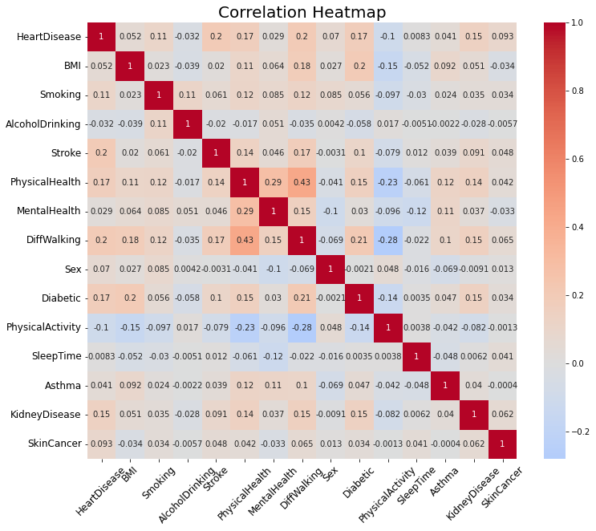

```python
fig, ax = plt.subplots(figsize=(12, 10))
sns.heatmap(data_binary.corr(), cmap='coolwarm', center=0, annot=True)
ax.set_title('Correlation Heatmap', fontsize=20)
ax.tick_params(labelsize=12)
plt.xticks(rotation=45)
plt.show()
```

## Principal Component Analysis (PCA)

```python
from sklearn.decomposition import PCA
import matplotlib.pyplot as plt

pca = PCA(n_components=2)
X_pca = pd.DataFrame(pca.fit_transform(X_train_scale),
               columns = ['PC 1', 'PC 2'])
X_pca.head(6)

PC1 = pca.fit_transform(X_train_scale)[:,0]
PC2 = pca.fit_transform(X_train_scale)[:,1]
ldngs = pca.components_

scalePC1 = 1.0/(PC1.max() - PC1.min())
scalePC2 = 1.0/(PC2.max() - PC2.min())
features = X_train.columns
```

[figure not shown]

```python
fig, ax = plt.subplots(figsize=(14, 9))

for i, feature in enumerate(features):
    ax.arrow(0, 0, ldngs[0, i],
             ldngs[1, i],
             head_width=0.03,
             head_length=0.03)
    ax.text(ldngs[0, i] * 1.15,
            ldngs[1, i] * 1.15,
            feature, fontsize = 18)

scatter = ax.scatter(PC1 * scalePC1,
                     PC2 * scalePC2,
                     c=y_train,
                     cmap='viridis')

ax.set_xlabel('PC1', fontsize=20)
ax.set_ylabel('PC2', fontsize=20)
ax.set_title('Figure 1', fontsize=20)

legend1 = ax.legend(*scatter.legend_elements(),
                    loc="lower left",
                    title="Groups")
ax.add_artist(legend1)
```

[figure not shown]

```python
plt.figure(figsize=(14,9))

for i, feature in enumerate(features):
    plt.arrow(0, 0, ldngs[0, i],
             ldngs[1, i],
              head_width=0.03,
             head_length=0.03)
    plt.text(ldngs[0, i] * 1.15,
            ldngs[1, i] * 1.15,
            feature, fontsize=18)

sns.scatterplot(x=PC1 * scalePC1,
                y=PC2 * scalePC2,
                hue=y_train,
                palette="viridis")

plt.xlabel('PC1', fontsize=20)
plt.ylabel('PC2', fontsize=20)
plt.title('Figure 2', fontsize=20)
```

## L1 regularization